# Food Consumption and CO2 Emissions

# Analysis for countries and specific food categories

However, we want to make use of the data we have and look at countries and their individual food categories. Again, running our K-Means clustering based on both total consumption and CO2 emissions per country and food categories, we are able to see what food categories in each country are responsible for high levels of CO2 emissions.

```r
#Assessing the plots above, we can see that 4 clusters is the optimal number
km.final <- kmeans(food.consumption.scaled, centers = 4, nstart = 25)

tibble("Between sum of squares to total sum of squares ratio" = km.final$betweenss / km.final$totss) %>%
  kable()
```

| Between sum of squares to total sum of squares ratio |
| --- |
| 0.8126998 |

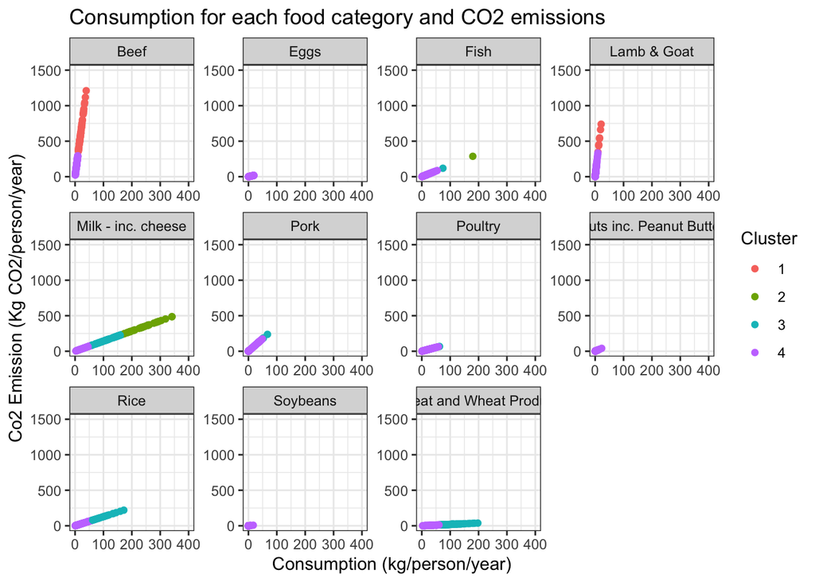

```r
#After getting our clusters, we are now appending it to our original dataframe
food.consumption.clusters <- food.consumption %>%
  mutate(Cluster = as.factor(km.final$cluster))

#Plotting out data
food.country.plot <- food.consumption.clusters %>%
  mutate(food_category = factor(food_category, levels = c("Beef", "Eggs", "Fish", "Lamb & Goat", "Milk - inc. cheese", "Pork",   "Poultry", "Nuts inc. Peanut Butter", "Rice", "Soybeans", "Wheat and Wheat Products"))) %>%
  ggplot(aes(x = consumption,
             y = co2_emmission,
             colour = Cluster)) +
  geom_point() +
  facet_wrap(~food_category,
             scales = "free") +
  scale_y_continuous(limits = c(0, 1500)) +
  scale_x_continuous(limits = c(0, 400)) +
  labs(x = "Consumption (kg/person/year)",
       y = "Co2 Emission (Kg CO2/person/year)",
       title = "Consumption for each food category and CO2 emissions") +
  theme_bw()

food.country.plot
```

```r
#Calculating the mean consumption for each cluster, along with the mean Co2 emissions for each cluster
food.country.cluster.analysis <- food.consumption.clusters %>%
  select(-country, -food_category) %>%
  group_by(Cluster) %>%
  summarise_all(mean) %>%
  arrange(desc(co2_emmission))

food.country.cluster.analysis %>%
  kable()
```

| Cluster | consumption | co2_emmission |
| --- | --- | --- |
| 1 | 20.50238 | 639.67460 |
| 2 | 242.95000 | 346.83175 |
| 3 | 105.99878 | 89.88864 |
| 4 | 11.53086 | 33.03619 |

# Analysis of non-animal product consumption

To answer our second research question, it was important to firstly look at the countries that consumed the highest number of non-animal products. In order to account for different levels of consumption between countries, looking at the *proportion of non-animal consumption compared to total consumption* was determined to be a more meaningful measure. By plotting 100 of our 130 countries below, we are able to see the relationship between the proportion of their non-animal consumption compared to total consumption, and their overall ranking in terms of total CO2 emissions from food consumption shows a positive relationship between the two. Labels were also added to countries who had a proportion of non-animal consumption compared to total consumption greater than 0.5. To strengthen this, we have also calculated Pearson’s correlation coefficient between the two variables, attaining a value of 0.71, indicating a moderately strong positive relationship.

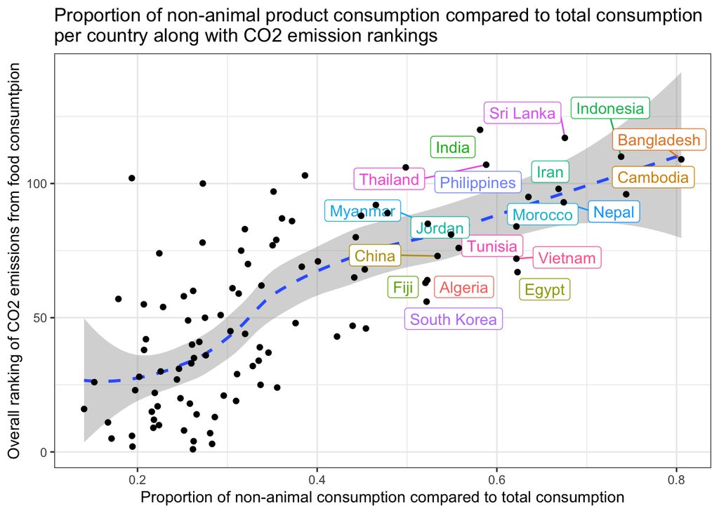

```r
#Ranking each country based on total CO2 emissions
country.rankings <- food.consumption.by.country %>%
  arrange(desc(total_emission)) %>%
  select(country) %>%
  mutate(ranking = seq(from = 1, to = 130))

#By removing the bottom 30 based on consumption, we are accounting only for countries who consume a reasonable amount for the purpose of our analysis
top.countries.total.emission <- arrange(food.consumption.by.country, desc(total_consumption))[1:100, ]

#We will now calculate for all countries which countries consume the most amount of non-animal products
top.nonanimal.consumption <- food.consumption %>%
  #Only looking at countries who consume a reasonable amount for the purpose of our analyis
  filter(country %in% top.countries.total.emission$country) %>%
  filter(food_category == "Wheat and Wheat Products" | food_category == "Rice" | food_category == "Soybeans" | food_category == "Nuts inc. Peanut Butter") %>%
  group_by(country) %>%
  #Getting our total non-animal consumption for each country
  summarise(total_nonanimal_consumption = sum(consumption))%>%
  #Adding our total consumption calculated eariler into this table
  left_join(food.consumption.by.country) %>%
  #Calculating the proportion of non-animal consumption compared to total consumption
  mutate(non_animal_proportion = total_nonanimal_consumption / total_consumption) %>%
  select(country, non_animal_proportion) %>%
  #Sort them based on total non-animal product consumption
  arrange(desc(non_animal_proportion))

#By completing a left join, we are able to compare non-animal products consumption and their rankings compared to all countries in terms of CO2 emissions
non.animal.proportion.rankings <- left_join(top.nonanimal.consumption, country.rankings) %>%
  arrange(desc(non_animal_proportion))

#Plotting the data
non.animal.proportion.rankings.plot <- non.animal.proportion.rankings %>%
  ggplot(aes(x = non_animal_proportion,
             y = ranking)) +
  geom_smooth(stat = "smooth",
              linetype = "dashed") +
  geom_label_repel(data = subset(non.animal.proportion.rankings, non_animal_proportion > 0.5),
                   aes(label = country,
                       color = country)) +
  geom_point() +
  labs(x = "Proportion of non-animal consumption compared to total consumption",
       y = "Overall ranking of CO2 emissions from food consumtpion",
       title = "Proportion of non-animal product consumption compared to total consumption \nper country along with CO2 emission rankings") +
  theme_bw()

non.animal.proportion.rankings.plot + theme(legend.position = "none")
```

```r
#Calculating Pearson's correlation coefficient
tibble("Pearson's Correlation Coefficient" = cor(non.animal.proportion.rankings$non_animal_proportion, non.animal.proportion.rankings$ranking)) %>%
  kable()
```

| Pearson’s Correlation Coefficient |
| --- |
| 0.7088274 |

# Conclusion

After performing our analysis, we were able to gain a clear idea of what countries and food categories were responsible for a considerable amount of CO2 emissions. While we were able to gain a list of countries that exhibited high levels of CO2 emissions, what was more insightful to focus on was the different food categories. Beef, lamb and goat were the food categories that were responsible for high levels of CO2 emissions in a number of countries.

Moreover, there is a clear relationship between the proportion of non-animal consumption compared to total food consumption, along with CO2 emissions. Our analysis strongly suggests that countries who consume more non-animal products tend to emit lower amounts of CO2 relative to other countries.

With this analysis we hope that countries can understand the importance of their food choices, and ideally encourage people to consider what they regularly to consume in hopes of slowing down climate change. This could be achieved through a number of different ways, including *decreasing the price of non-animal products, raising awareness on the benefits of consuming non-animal products for both the individual as well as the climate, and also improving accessibility of these products.*